# Geogia Film Tax Incentives - Economic Impacts

## **Film Industry: Film Tax Incentives, Industry Performance, and Economic Impact**

### **Tram Nguyen**

[video not shown]

### **👉 [Link to Power BI Dashboard](https://github.com/jamienguyen215/georgia-film-tax-incentive/blob/main/Georgia%20Film%20Tax%20Incentives%20-%20Economic%20Impacts.pbix)**

#### **Table of Content**

**1. Introduction**

```
1.1  Film Industry in Georgia
1.2  Film Industry Sector and Definition
1.3  Film Tax Incentives
```

**2. Research Objectives**

**3. Approach**

**4. Results**

```
4.1  Georgia Film Industry Performance
   4.1.1  Georgia Film Industry Performance in terms of Jobs
   4.1.2  Georgia Film Industry Performance in terms of Total Annual Wages
   4.1.3  Georgia Film Industry Performance in terms of Average Weekly Wages
   4.1.4  Georgia Film Industry Performance in terms of Firms
4.2  Georgia Film Industry by Sector Performance
   4.2.1  Georgia Film Industry Performance by 4-digit NAICS code
   4.2.2  Georgia Film Industry Performance by 5-digit NAICS code
4.3  Georgia Film Industry by Sector Performance
   4.3.1  The Input-Output Model
   4.3.2  The Input-Output Model Analysis Results
```

**5. Conclusion**

**References**

### **1. Introduction**

#### **1.1 Film Industry in Georgia**

Georgia has been one of the main locations for various productions, but it was not until the movie “Deliverance”, based on James Dickey’s novel and directed by John Boorman, was released in 1972 that Georgia caught Hollywood’s attention, and Georgia Film Industry began its history.

In 2016, Georgia earned its title “Hollywood of the South” by beating California and becoming the top location for feature film production.

In 2017, the economic impact of the film industry on Georgia was `$9.5 billion`, with 92,000 jobs and `$4.6 billion` worth of wages created.

Some well-known movies and series that were shot in Georgia are “Forrest Gump”, “The Walking Dead”, and “Avengers: Endgame”.

#### **1.2 Film Industry Sector and Definition**

Film Industry was identified in this analysis by the use of NAICS code. NAICS (North American Industry Classification System) code was developed jointly by the U.S. Economic Classification Policy Committee (ECPC), Statistics Canada, and Mexico's Instituto Nacional de Estadistica y Geografia, with the aim of collecting, analyzing, and publishing statistical data related to the U.S business economy. <sup>(1)</sup>

The code that describes the film industry as a whole is 512, which stands for “Motion Picture and Sound Recording Industries”. From this 3-digit code, the two 4-digit codes that are used for the two main parts of the film industry, Motion Picture and Sound Recording, are 5121, representing “Motion Picture and Video industries”, and 5122 for “Sound Recording Industries”.

#### **1.3 Film Tax Incentives**

Film Tax Incentives were first adopted in Georgia when Georgia’s General Assembly and Governor approved the Georgia Entertainment Industry Investment Act in 2005. Projects meeting the total expenditures’ requirement of `$500,000` were eligible to receive a base tax credit of 9%. Film, video, or digital projects such as feature films, series, pilots, movies for television, commercial advertisements, music videos, interactive entertainment, or sound recording for these projects were listed as qualified production activities (Bradbury, 2019).

On May 9, this law became effective with the Governor’s approval. The base tax credit was adjusted to 20% by lawmakers in 2008. According to this amendment, the total tax credit could be up to 30% by adding 10% by including a promotional logo, and the requirement for in-state expenditures remains the same. Since 2008, the application of film tax incentives has been similar to the act amendment.

The first state to adopt film tax incentives was Louisiana in 1992. In 2005, Georgia, along with Utah, Montana, Oklahoma, Rhode Island, and New Jersey, adopted film tax incentives.

### **2. Research Objectives**

The analysis was done to answer the following questions:

- How has the film industry in Georgia been performing under the influence of film tax incentives?
- What is the economic impact of the film industry in Georgia?

### **3. Approach**

Following the objectives, three analyses were developed to address the issues. - Analyze the Georgia Film Industry: Examine the Georgia Film Industry's performance in terms of jobs, wages, and firms from 2005 to 2019 to discover if the tax incentives had any effect.

The primary data sources for the first two approaches are “Quarterly Census of Employment and Wages (QCEW)” data from the Bureau of Labor Statistics and “Statistics of the U.S. Business” data from the United States Census Bureau. The “Input-Output” data from the Bureau of Economic Analysis are utilized to tackle the issues in the last approach.

### **4. Results**

#### **4.1. Georgia Film Industry Performance**

From 2005 to 2019, besides the two main events of film tax incentives in 2005 (9 percent tax incentives) and 2008 (tax incentives amendment to 30 percent), the event in 2014 also had a significant impact on the Georgia film industry.

In 2014, realizing the potential and benefits of filmmaking in Georgia, two well-known and big studios - Pinewood Studios and Marvel Studios - came to Georgia and brought plenty of projects.

Marvel Studios is an American film and television production company that is a subsidiary of Walt Disney Studios. It is well known for producing various Marvel superhero movies such as Iron Man, X-Men, Captain America, Spider-Man, and The Avengers. Pinewood Studios is a British film and television production company. In April 2013, it announced the construction of Pinewood Atlanta Studios (now Trilith), a 235-acre location in Fayette County (Georgia). Pinewood Studios collaborated with Marvel Studios to make their first movie, Ant-Man, in 2014 <sup>(2)</sup> . Since then, the two studios have continued working on a series of famous Marvel films, including Captain America: Civil War (2016), Spider-Man: Homecoming (2017), Black Panther (2018), and Avengers: Endgame (2019), among others.

#### **4.1.1. Georgia Film Industry Performance in terms of Jobs.**

The number of direct jobs in the Georgia Film Industry fell by 5% between 2005 and 2008. The 9 percent tax incentives did not affect employment creation. From 2008 to 2014, the number of direct jobs rose by 36% after amending the tax incentives to 30% in 2008. When Pinewood Studios and Marvel Studios came to Georgia in 2014, the direct jobs increased by

154% between 2014 and 2019. After 11 years of implementing the 30% tax incentives, from 2008 to 2019, the increase rate was 246 percent for direct jobs in the film industry.

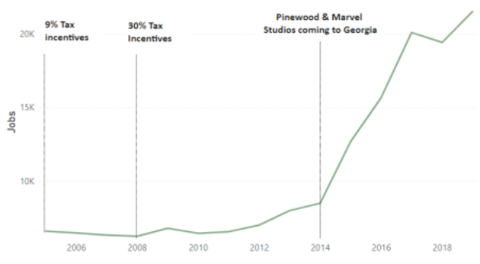

*Figure 1: Direct Jobs in Georgia Film Industry (2005 - 2019)*

#### **4.1.2. Georgia Film Industry Performance in terms of Total Annual Wages**

[figure not shown]

#### **4.1.3. Georgia Film Industry Performance in terms of Average Weekly Wages**

To examine the average weekly wages more precisely, "Motion pictures and video Exhibition - 51213" were eliminated from this calculation since their data values are very low in comparison to other sectors. According to careeronestop (United States Department of Labor), "Motion pictures and video Exhibition" is also listed as the industry that has the lowest average weekly wages in Georgia

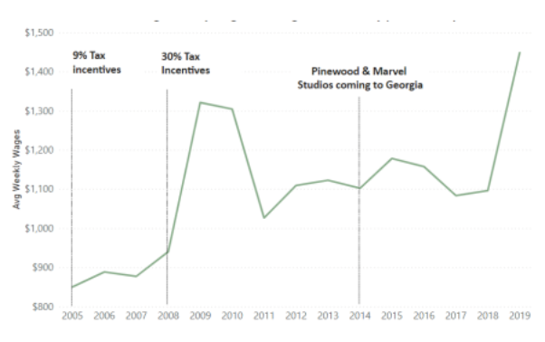

*Figure 3: Direct Average Weekly Wages in Georgia Film Industry (2005 - 2019)*

The average weekly wage in the Georgia film industry climbed by 11% between 2005 and 2008. It rose by 17% between 2008 and 2014. It increased by 31% between 2014 and 2019. And it increased by 54% between 2008 and 2019. In 2019, the average weekly pay in Georgia was around `$1,025`, while the Film Industry was `$1,449`, which is 1.41 times higher.

#### **4.1.4. Georgia Film Industry Performance in terms of Firms**

Unlike Jobs and Wages, the number of Firms in the Georgia Film Industry just gradually expanded over time. From 2005 to 2008, the number of firms climbed by 13%. From 2008 to 2014, it increased by 12%. From 2014 to 2019, it increased by 19%. And from 2008 to 2019, the number of Georgia Film Industry firms increased by 33%.

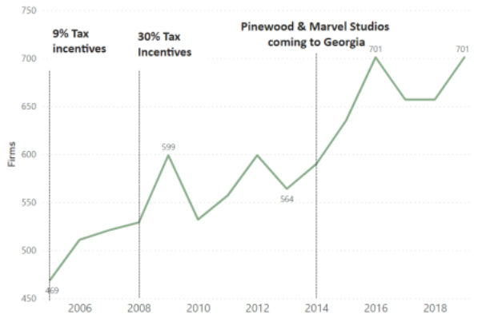

*Figure 4: Georgia Film Industry Firms (2005 - 2019)*

Georgia increased from 2.4% in 2005 to 2.9% in 2019 of Total Film Industry Firms in the United States. Georgia Film Industry Firms' development trend is quite similar to the trend of the industry as a whole in the United States.

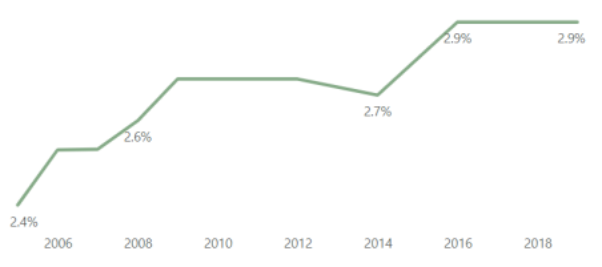

*Figure 5: %Film Industry Firms in Georgia vs U.S. (2005 - 2019)*

A firm may have one or more establishments. The chorology of the number of firms/establishments in the Georgia Film Industry by County shows that, throughout time, the majority of firms/establishments concentrated in the Atlanta Metropolitan area. In 2019, this

area was home to 80 % of the firms/establishments. From 2005 to 2019, the percentage of establishments by area did not vary much. However, the number of establishments in each county increased. In 2019, Fulton County had 267 establishments, Dekalb County had 101 establishments, Cobb County had 78 establishments, Gwinnett County had 71 establishments, Chatham County had 21 establishments, and Cherokee, Fayette, Henry, and Clarke all had more than ten.

[figure not shown]

*Figure 6: Number of Firms/Establishments in Georgia Film Industry by County 2019*

### **4.2. Georgia Film Industry by Sector Performance**

#### **4.2.1. Georgia Film Industry Performance by 4-digit NAICS code**

In the chart showing the percentage of firms in Georgia’s film industry by sector (NAICS 5121 for Motion Picture and Video Industries, NAICS 5122 for Sound Recording Industries), considering the data of 2008, 2014, 2017, and 2019, 75% to 80% of firms belong to the sector Motion Picture and Video Industries. From 2008 (when the Act Amendment happened) to 2014, there was an upward trend in the number of firms in Motion Picture and Video Industries and a downward trend in that of Sound Recording Industries. This indicates that the change in tax credit affected the Motion Picture and Video Industries significantly by creating more firms.

After 2014, both sectors saw an upward trend, and this could be explained by the increase in the number of major productions filmed in Georgia, innovations in Dolby sound technology, and digital marketing with social media and video platforms like Facebook, Youtube, Vimeo, TikTok, etc.

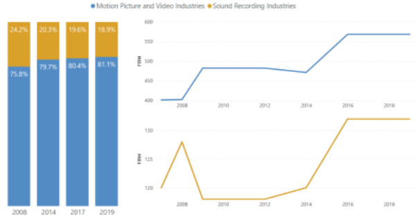

*Figure 7: Firms by Film Industry Sector in Georgia (2007 - 2019)*

The percentage of firms in Sound Recording Industries in Georgia compared to the total US increased from 3.33% in 2007 to 3.7% in 2019, while the percentage of firms in Motion Picture and Video Industries in Georgia compared to the total of US increased from 2.4% in 2007 to 2.7% in 2019. This happened due to the fact that the music industry in Georgia has long been established since the early 1900s, and most firms in Motion Picture and Video Industries were still located around center areas of the US’s film industry like California and New York.

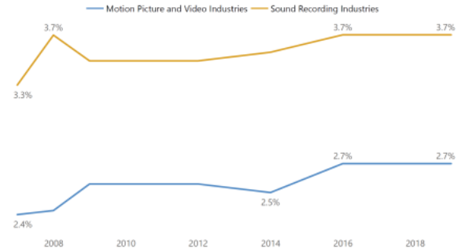

*Figure 8: Percentage of Firms by Film Industry Sector in Georgia compared to U.S (2007 - 2019)*

Firm size was categorized by the number of employees:

- Firms with less than 5 employees: Micro
- Firms with 5 to 99 employees: Small
- Firms with 100 to 499 employees: Medium
- Firms with 500 or more employees: Large

Both the Motion Picture and Video Industries and Sound Recording Industries sectors had more firms in micro and small sizes. Especially for the Motion Picture and Video Industries sector, the increase in the number of micro and small firms was significant. In 2019, 95% of firms in the Motion Picture and Video Industries and Sound Recording Industries sectors were in micro and small sizes. This indicates that film tax incentives gave individuals the opportunity to establish their own independent firms of smaller sizes.

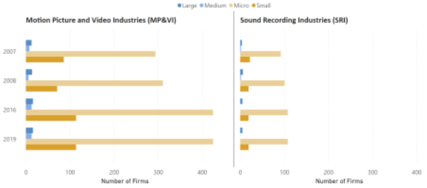

*Figure 9: Firm Size by Film Industry Sector in Georgia (2007 - 2019)*

#### **4.2.2. Georgia Film Industry Performance by 5-digit NAICS code**

For each main sector in the film industry, only three 5-digit codes representing three sub-sectors were considered to understand the performance of the sector in detail. The performance of these sub-sectors was observed based on the number of jobs, number of firms, annual wages, and average weekly wages.

Within Motion Picture and Video Industries, the three sectors used for the analysis were Motion Picture and Video Exhibition (NAICS 51213) (including theaters, film festivals), Motion Picture and Video Production (NAICS 51211) (including directors, writer, actors, cameramen, artists), and Post-production & other industries (NAICS 51219) (including editing, dubbing, subtitling, graphics, effects).

Production has always been the core of the film industry, so the values for this sector in all factors were comparatively high.

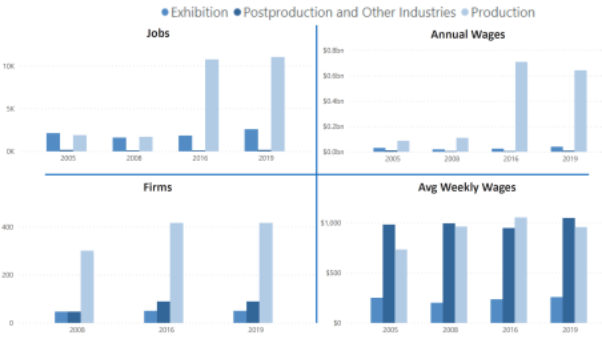

*Figure 10: Motion Picture and Video Industries Performance by sectors (2005 - 2019)*

For Sound Recording Industries, the three sectors used for the analysis were Music Publishers (NAICS 51223) (including music publishing, copyright owning and managing, licensing), Record Production & Distribution (NAICS 51225) (including producing and mastering recordings, promotion and distribution), and Sound Recording Studios (NAICS 51224) (including studios with facilities and technical devices).

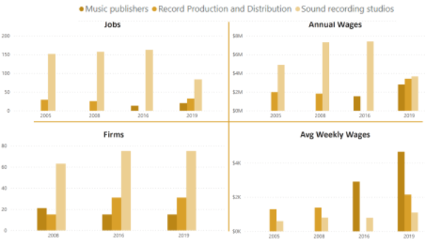

*Figure 11: Sound Recording Industries Performance by sectors (2005 - 2019)*

### **4.3. The relationship between the film industry and other industries.

#### 4.3.1. The Input-Output Model**

The Input-Output Model is a macroeconomic analysis based on the interdependence of various economic sectors or industries <sup>(5)</sup> . The idea is that an increase in economic activity in the film industry will lead to subsequent rounds of spending/requirements from other industries. For example, if there are incentives to produce more movies, demand for Building Sets, Catering and Food Serving, Clothes Making, Actors/Actresses, and so on will rise.

This paper applied partially the input-output model by using only the “Use Table” and “Direct Requirement Table” from the “Input-Output” data (Bureau of Economic Analysis) to see how an increase in the total output of the Film Industry will require input from other industries.

*The use table* shows the components/commodities that are necessary for producing the output of each industry. *The direct requirements table* shows the amount of a commodity that is required by an industry to produce a dollar of the industry’s output. <sup>(6)</sup>

#### **4.3.2. The Input-Output model analysis results**

Considering the high cost of obtaining *the use table* and *the direct requirements table* for the Georgia region, this paper instead relied on data available for the whole United States. As a result, an assumption was established to help assess the economic impact of the Georgia Film Industry. The assumption is that the composition of other industries' input to produce output in the Film Industry in Georgia and the United States is the same. The similar growth trend between Georgia Film Industry Firms and the US in the preceding analysis somewhat validates this assumption.

Georgia Film Industry was mentioned more than ever in 2017 since its total output reached `$9.5 billion` . It is the highest output ever produced by the Georgia Film Industry. That year, the overall Film Industry in the United States was around `$148 billion`, implying that Georgia accounted for approximately 6.4 percent of the total. Fifty states adopted film tax incentives; the average percentage for each state should be 2%, but Georgia got more than three times that amount in 2017.

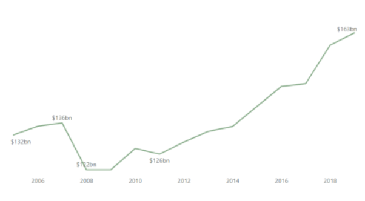

*Figure 12: Total Film Industry Output in the U.S (2005 - 2019)*

From The Use Table, the top industries that contributed the most input to generate the total output of the U.S Film Industry in 2017 are obtained:

- Motion picture and sound recording industries - `$19 billion`.
- Miscellaneous professional, scientific, and technical services industries: the industry requires a high degree of expertise and training; activities performed include: legal advice and representation; accounting, bookkeeping, and payroll services; architectural, engineering, and specialized design services; computer services; consulting services; research services; advertising services; photographic services; translation and interpretation services; veterinary services; and other professionals, scientific, and technical services - `$11 billion`
- Performing arts, spectator sports, museum and related activities industries: actors and actresses, singers, dancers, musical groups and artists, athletes, and other entertainers - `$7 billion`.
- Other real estate industries: Storages, Studios, Houses, etc. - `$4 billion`.
- Rental and leasing services and lessors of intangible assets industries: Renting Tools/ Devices/ Equipment/ Patents/ Trademarks, etc. - `$3 billion`.
- Administrative and support services industries: General Management, Administration, Cleaning activities, etc. - `$2 billion`.
- Federal Reserve Banks, Credit Intermediation and related activities industries: loans, etc - `$1 billion`.
- Insurance Carriers and related activities industries: `$1 billion`.
- Other transportation and support activities industries: `$1 billion`.

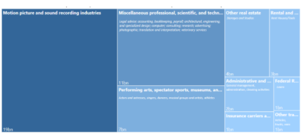

*Figure 13: Input from Specific Industries to Create Total Output of U.S Film Industry (2017)*

The input requirements from other industries and employees to generate a `$1` dollar output in the U.S Film Industry in 2017 were:

- 23 cents from Compensation of Employees
- 13 cents from the Motion picture and sound recording industries.
- 7 cents from Miscellaneous professional, scientific, and technical services industries: - 4 cents from Performing arts, spectator sports, museums, and related activities industries
- 3 cents from Other real estate industries
- 2 cents from Rental and leasing services and lessors of intangible assets industries
- 1 cent from Administrative and support services industries.
- 1 cent from Federal Reserve Banks, Credit Intermediation, and related activities industries
- 1 cent from Insurance Carriers and related activities industries.
- 1 cent Other transportation and support activities industries.
- 4 cents from other industries.

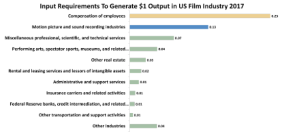

*Figure 14: Input Requirements to Generate `$1` Output in U.S Film Industry (2017).*

Georgia's output in the Film Industry in 2017 was `$9.5 billion`. It might have required `$2.17 billion` from Compensation of Employees,`$1.21 billion` from Film Industry, `$680 million` from Professional Services, `$420 million` from Performing Arts, `$250 million from Real Estate`, `$180 million` from Rental, `$140 million` from Administrative, `$80 million` from Insurance, `$70 million` from Banks, `$50 million` from Transportation, `$420 million` from Other industries.

### **5. Conclusion**

Film Tax Incentives had a great influence on the Georgia Film Industry. From 2008 to 2019, it increased by 246% in the number of jobs, 488% in total annual wages, 54% in average weekly wages, and 33% in the number of Firms.

After 2008, Motion Picture & Video Industries increased by 42% in the number of firms, while Sound Recording Industries only increased by 3%. Firm Size focused more on Small to Micro.

In the sector Motion Picture and Video Industries (NAICS 5121), Post-production & other industries sector had the highest Average Weekly Wages, and Production sector had the highest number of jobs, annual wages, and firms.

In 2017, Georgia Film Industry might have created around `$2.17 billion` for employee’s wages, `$1.21 billion` for the film industry, and `$2.29 billion` for other industries.

### **References**

Bradbury, J. C. (2019). Film tax credits and the economic impact of the film industry on Georgia’s economy. *SSRN Electronic Journal* . https://doi.org/10.2139/ssrn.3407921

New York City Film & Television Industry Economic Impact Study 2021 https://www1.nyc.gov/assets/mome/pdf/mome-nyc-film-tv-industry-study-report.pdf

B. William Riall, Ph.D. Economic and Fiscal Impact Analysis of the Music Industry in Georgia, May 2011

http://georgiamusicpartners.org/wp-content/uploads/2011/04/Georgia-Music-Business-Econo mic-Impact-Study-FINAL.pdf

(1) https://www.census.gov/naics/

(2) Pinewood Atlanta Studios Rebrands as Trilith, Builds Out 235-Acre Neighboring Town https://www.hollywoodreporter.com/movies/movie-news/pinewood-atlanta-studios-rebrands -as-trilith-builds-out-235-acre-neighboring-town-4072451/

(3) Highest-Paying Industries in Georgia

https://www.careeronestop.org/Toolkit/Industry/highest-paying-industries.aspx?location=G A&currentpage=2&pagesize=500

(4) Average Weekly Wage of Georgia in 2019, Quarter 3

https://www.beautifydata.com/economics/united-states/average-weekly-wages/by-county-pe r-quarter/georgia/2019/q3

(5) Input-Output Analysis https://www.investopedia.com/terms/i/input-output-analysis.asp (6) Concepts and Methods of the U.S. Input-Output Accounts

https://www.bea.gov/sites/default/files/methodologies/IOmanual_092906.pdf (7) Film industry generates $9.5 billion for Georgia's economy

https://www.georgia.org/newsroom/press-releases/film-industry-generates-9-5-billion-georg ias-economy

(8) Professional, Scientific, and Technical Services https://www.bls.gov/iag/tgs/iag54.htm